# 데이터 개요

yoda

2017년 9월 4일

### 1. 데이터 수집 및 처리

http://www.cetizen.com/ 에서 파이썬을 통한 크롤링으로 중고폰 판매 게시글의 데이터를 2014년 5월 18일부터 2017년 9월 1일까지 수집했다.

1차적으로 분석 휴대폰 기종을 아이폰으로 선택하여 아이폰만 있는 데이터 테이블을 형성한 후,

2차적으로 2016년 11월 30일의 물품 ID 16186605 이전에는 필요한 컬럼들이 전부 NULL값이므로 2016년 11월 30일의 물품 ID 16186605 이후의 데이터들만 최종적으로 추려서 분석 데이터로 사용한다.

```r
data1 <- read.csv("perfact2.csv")
str(data1)
```

```
## 'data.frame':    38912 obs. of  18 variables:
##  $ ID         : int  16186605 16186608 16186617 16186621 16186632 16186644 16186673 16186674 16186678 16186679 ...
##  $ POSTDATE   : Factor w/ 276 levels "2016-11-30","2016-12-01",..: 1 1 1 1 1 1 1 1 1 1 ...
##  $ MODEL      : Factor w/ 13 levels "A1303","A1332",..: 10 13 12 8 11 9 4 10 8 8 ...
##  $ GB         : Factor w/ 6 levels "128GB","16GB",..: 2 1 4 2 5 5 4 5 5 5 ...
##  $ KRNAME     : Factor w/ 13 levels "아이폰 3GS","아이폰 4",..: 9 12 11 7 13 10 4 9 7 7 ...
##  $ POSTPRICE  : int  390000 1030000 780000 230000 370000 510000 75000 420000 270000 300000 ...
##  $ CONTRACT   : Factor w/ 3 levels "모름","요금할인약정 가능",..: 1 1 1 1 1 1 1 1 1 1 ...
##  $ GUARANTEE  : Factor w/ 3 levels "무상 보증기간 남음 ",..: 1 1 1 3 1 2 2 3 2 2 ...
##  $ CHANGES    : Factor w/ 2 levels "유심기변","확정기변": 2 1 1 1 2 2 2 2 2 2 ...
##  $ CONDITIONS : Factor w/ 4 levels "미사용","상(새제품 수준/무흠집)",..: 2 1 1 2 2 2 3 3 2 3 ...
##  $ COMPONENT  : Factor w/ 3 levels "구성품 일부 누락",..: 1 1 1 1 1 1 1 1 3 1 ...
##  $ SOLD       : Factor w/ 2 levels "no","yes": 2 1 1 2 1 1 1 2 2 1 ...
##  $ RELDATE    : Factor w/ 10 levels "2009-11-28","2010-09-10",..: 7 9 9 6 8 7 4 7 6 6 ...
##  $ NEXTGENDATE: Factor w/ 10 levels "2010-09-10","2011-11-11",..: 7 9 9 6 8 7 4 7 6 6 ...
##  $ POSTRELGAP : int  404 40 40 761 204 404 1454 404 761 761 ...
##  $ POSTNEXTGAP: int  204 -128 -128 404 40 204 1132 204 404 404 ...
##  $ RELPRICE   : int  869000 1152800 869000 789800 699600 1130800 946000 999900 924000 924000 ...
##  $ FALLRATE   : num  55.1 10.7 10.2 70.9 47.1 54.9 92.1 58 70.8 67.5 ...
```

총 18개 변수(컬럼)에 38912개의 데이터로 이루어져 있다.

### 2. 각 변수(컬럼) 설명

ID : 판매불품 별 고유 번호

POSTDATE : 물품 판매 게시 날짜

MODEL : 물품 모델명

GB : 메모리량

KRNAME : 한국모델명

POSTPRICE : 중고판매가격

CONTRACT : 요금할인약정 여부

GUARNTEE : A/S 보증기간 여부

CHANGES : 기기변경 종류(확정, 유심)

CONDITIONS : 물건 상태

COMPONENT : 구성품 여부

SOLD : 판매 여부

RELDATE : 해당 ID의 제품 출고날짜

NEXTGENDATE : 해당 ID의 제품 다음 모델의 출고날짜.

(ex: 해당 판매제품 모델이 아이폰3이면 아이폰4의 출고날짜값을 갖는다.)

POSTRELGAP : 판매게시날짜(POSTDATE) - 해당제품 출고날짜(RELDATE).

판매자가 해당제품을 출고날부터 어느정도 지난 후 판매하는지에 대한 값.

POSTNETGAP : 판매게시날짜(POSTDATE) - 다음 모델의 출고날짜(RELDATE).

양수일 경우 다음 모델이 출시된 후에 판매하고 음수일 경우 다음 모델 출시 전에 판매

RELPRICE : 해당제품 출고가

FALLRATE : 출고가격대비 가격 감소율

### 3. boxplot을 통한 모델과 기종별 가격 확인

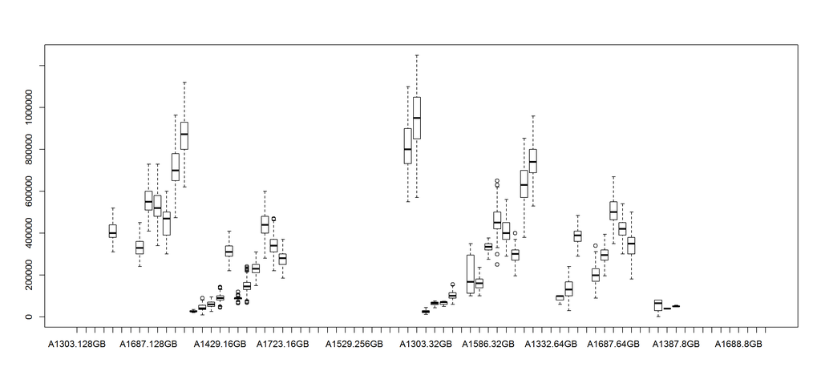

```r
box <- boxplot(POSTPRICE~MODEL+GB, data=data1)
```

### 4. 출고일부터 판매시점(POSTRELGAP)에 따른 가격 변화 확인

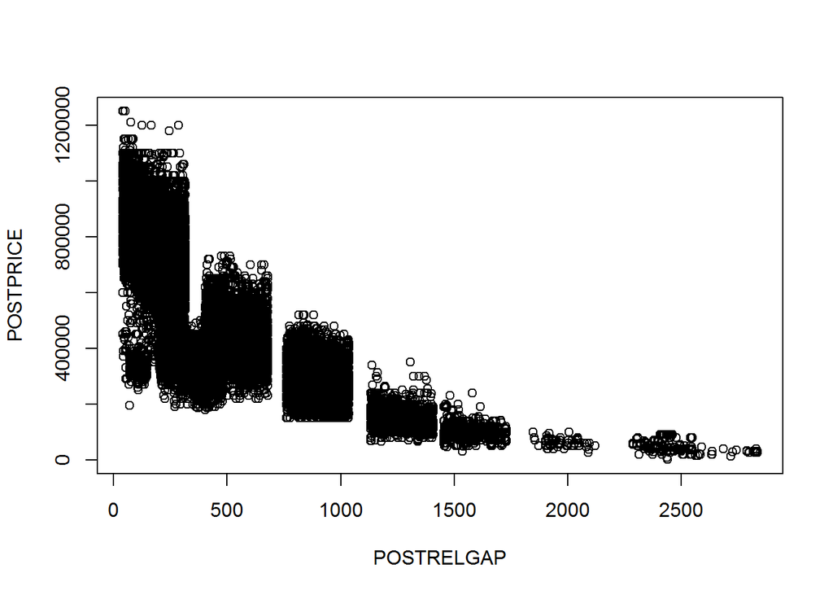

```r
plot(POSTPRICE~POSTRELGAP, data=data1)
```

해당제품 출고일부터 나중에 판매할수록 가격이 떨어지는 것을 확인할 수 있다.